# Targeted enrichment and discovery of jumbo phages

Author

Jeffrey Blanchard

Published

May 4, 2023

# Overview

This report is an analysis of the Barre Woods filter metagenomes from the combined assembly Assembly, binning, quality control and classification was done on KBase (https://narrative.kbase.us/narrative/145971. The checkv and virsorter files were downloaded to this project folder.

**R code**

```r
# Load libraries
library(tidyverse)
library(DT)
```

## virsorter2 and vcheck

### Data processing

virsorter2 identifies dsDNAphages, NCLDV, ssDNA, virophages and some rna viruses in contigs. An 0.8 cutoff score is commonly used to remove potential false positives. checkv assesses the quality of contigs.

**R code**

```r
virsorter <- read_tsv("data_combined_assembly/virsorter-final-viral-score.tsv") |>
  filter(max_score_group == "dsDNAphage") |>
  select(-c(dsDNAphage, ssDNA, NCLDV, lavidaviridae)) |>
  rename("contig_id" = "seqname")

checkv <- read_tsv("data_combined_assembly/coa-checkv_quality_summary.tsv")
```

#### Join checkv and virsorter dataframes

**R code**

```r
virsorter_checkv <- left_join(virsorter, checkv, by = "contig_id")
```

#### filter to high quality and complete genomes

**R code**

```r
virsorter_checkv_HQ <- virsorter_checkv |>
  filter(checkv_quality == "Complete" | checkv_quality == "High-quality")
```

#### filter to HQ jumbo phages

**R code**

```r
virsorter_checkv_jumbo <- virsorter_checkv |>
  filter(checkv_quality == "Complete" | checkv_quality == "High-quality") |>
  filter(length >= 200000)
```

#### Write files

**R code**

```r
# write summary file
write_tsv(virsorter_checkv, "data_combined_assembly/coa-virsorter_checkv.tsv")
write_tsv(virsorter_checkv_HQ, "data_combined_assembly/coa-virsorter_checkv_HQ.tsv")
write_tsv(virsorter_checkv_jumbo, "data_combined_assembly/coa-virsorter_checkv_jumbo.tsv")
```

### Data analysis

#### Barchart of checkv_quality

**R code**

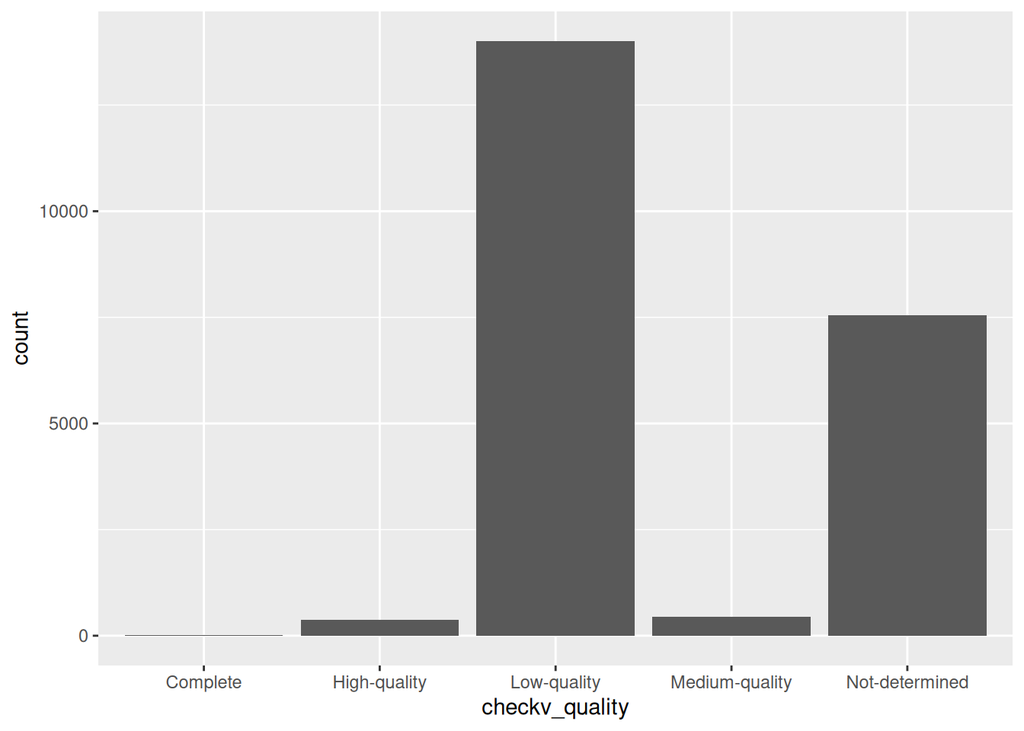

```r
virsorter_checkv |>
ggplot(aes(x = checkv_quality)) +
  geom_bar()
```

#### Table with % checkv_quality in each category

**R code**

```r
virsorter_checkv |>
  mutate(across(checkv_quality, as_factor)) |>
  group_by(checkv_quality) |>
  summarise(n = n()) |>
  mutate(freq = n / sum(n))
```

```
# A tibble: 5 × 3
  checkv_quality     n     freq
  <fct>          <int>    <dbl>
1 High-quality     372 0.0166
2 Complete          16 0.000714
3 Medium-quality   450 0.0201
4 Not-determined  7551 0.337
5 Low-quality    14012 0.626
```

#### Histogram of all contigs

Most low quality contigs are less than 20kb

**R code**

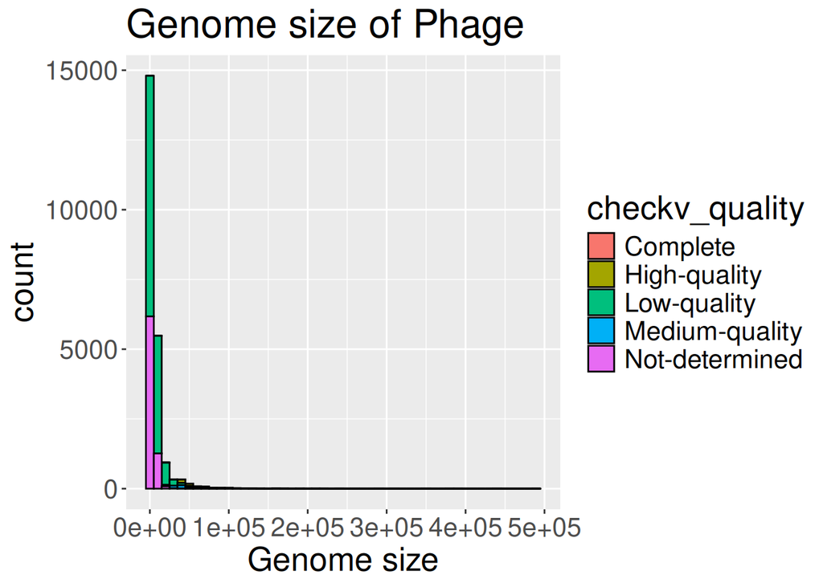

```r
virsorter_checkv |>
ggplot(aes(x = length, fill = checkv_quality)) +
  geom_histogram(colour = "black",  binwidth=10000) +
  ggtitle("Genome size of Phage") +
  xlab("Genome size") +
  theme(text = element_text(size = 20, color="black"))
```

**R code**

```r
  theme(axis.text.x = element_text(angle = 90))
```

[output not shown]

#### Histogram of HQ contigs

**R code**

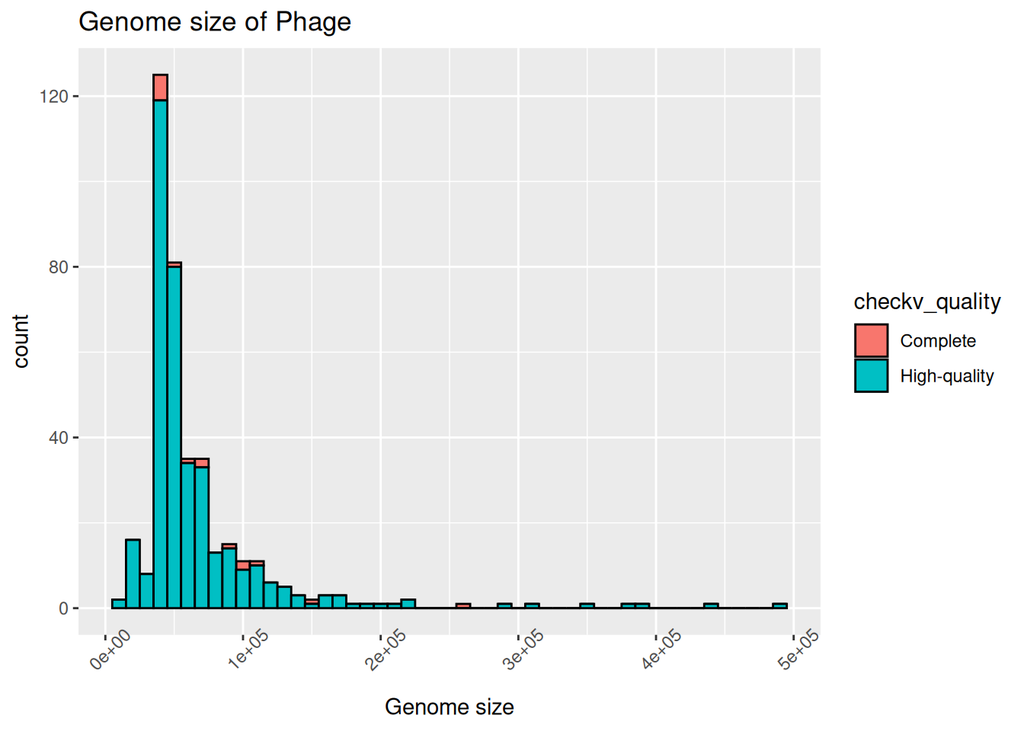

```r
virsorter_checkv_HQ |>
ggplot(aes(x = length, fill = checkv_quality)) +
  geom_histogram(colour = "black",  binwidth=10000) +
  ggtitle("Genome size of Phage") +
  xlab("Genome size") +
  #theme(text = element_text(size = 20, color="black"))
  theme(axis.text.x = element_text(angle = 45))
```

## Merging GTDB and binning data with virsorter2 and vcheck

**R code**

```r
# read metabat files to get each contig and gtdb file
metabat <- read_tsv("data_combined_assembly/metabat_depth_contigs.tsv")
checkm_gtdb <- read_tsv("data_combined_assembly/checkm_gtdb_NEB_coassembly_2.5k.tsv") |>
  select(-c(`Marker Lineage`,   `# Genomes`,    `# Markers`,    `# Marker Sets`, `0`,   `1`,    `2`,    `3`,    `4`,    `5`, `user_genome`))
```

**R code**

```r
# split contig name based on ||
virsorter_checkv_contig <- virsorter_checkv |>
   separate(`contig_id`, c("contig_id", "full-partial"), "\\|\\|")
# join with metabat
virsorter_checkv_contig_metabat <- left_join(virsorter_checkv_contig, metabat, by = c("contig_id" = "seqname"))
# join with checkm_gtdb
virsorter_checkv_contig_metabat_checkm_gtdb <- left_join(virsorter_checkv_contig_metabat, checkm_gtdb, by = c("bin"))
```

### contigs that mapped to HQ and MQ bins

**R code**

```r
virsorter_checkv_contig_metabat_checkm_gtdb_MQ <- virsorter_checkv_contig_metabat_checkm_gtdb |>
  filter(Completeness > 50) |>
  filter(Contamination < 10)

virsorter_checkv_contig_metabat_checkm_gtdb_noMQ <- virsorter_checkv_contig_metabat_checkm_gtdb |>
  filter(Completeness < 50)
```

## vContact

vContact groups contigs into clusters along with phages in NCBI’s viurs reference database ### data processing

#### read in files

**R code**

```r
vcontact <- read_csv("data_combined_assembly/vcontact_genome_by_genome_overview.csv")
vcontact_ntw <- read_table("data_combined_assembly/coa-vcontact_c1.ntw", col_names = FALSE)
```

#### join with virsorter and checkv results

**R code**

```r
virsorter_checkv_HQ_vcontact <- left_join(virsorter_checkv_HQ, vcontact, by = c("contig_id" = "Genome"))
virsorter_checkv_jumbo_vcontact <- left_join(virsorter_checkv_jumbo, vcontact, by = c("contig_id" = "Genome"))
```

#### filter network files to contain just HQ or jumbo phages for cytoscape

**R code**

```r
# make a vector of HQ and jumbo contigs
HQ_contigs <- pull(virsorter_checkv_HQ, contig_id)
jumbo_contigs <- pull(virsorter_checkv_jumbo_vcontact, contig_id)

# create list of low quality genomes
# There are genes in the vcontact network that are not in the merged virsorter/vcheck file
# So first make a list of vcontact genomes with contig in name then filter HQ

vcontact_contig_LQ <- vcontact |>
filter(grepl('Contig', Genome)) |>
filter(!Genome %in% HQ_contigs)

# make a vector of low quality contigs
LQ_contigs <- pull(vcontact_contig_LQ, Genome)

# filter vcontact network based on HQ genomes}
vcontact_ntw_HQ <- vcontact_ntw |>
filter(X1 %in% HQ_contigs) |>
filter(!X1 %in% LQ_contigs & !X2 %in% LQ_contigs)

# filter vcontact network based on jumbo genomes
vcontact_ntw_jumbo <- vcontact_ntw |>
filter(X1 %in% jumbo_contigs) |>
filter(!X1 %in% LQ_contigs & !X2 %in% LQ_contigs)

# filter vcontact network based on jumbo genomes and interaction score <30
vcontact_ntw_jumbo30 <- vcontact_ntw_jumbo |>
  filter(X3 > 30)
```

#### Write files

**R code**

```r
write_tsv(virsorter_checkv_HQ_vcontact, "data_combined_assembly/coa-virsorter_checkv_HQ_vcontact.tsv")
write_tsv(virsorter_checkv_jumbo_vcontact,"data_combined_assembly/coa-virsorter_checkv_jumbo_vcontact.tsv")
write.table(vcontact_ntw_HQ, "data_combined_assembly/vcontact_ntw_HQ.ntw", sep = " ", col.names=F, row.names=F, quote=F)
write.table(vcontact_ntw_jumbo, "data_combined_assembly/vcontact_ntw_jumbo.ntw", sep = " ", col.names=F, row.names=F, quote=F)
write.table(vcontact_ntw_jumbo30, "data_combined_assembly/vcontact_ntw_jumbo30.ntw", sep = " ", col.names=F, row.names=F, quote=F)
```

### Data Analysis

#### Histogram of interaction score

**R code**

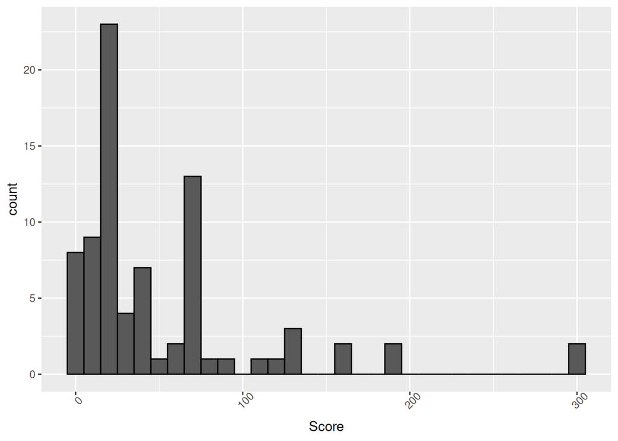

```r
vcontact_ntw_jumbo |>
ggplot(aes(x = X3)) +
  geom_histogram(colour = "black",  binwidth=10) +
  xlab("Score") +
  #theme(text = element_text(size = 20, color="black"))
  theme(axis.text.x = element_text(angle = 45))
```

## Cytoscape

### Notes

#### To load network

File > Import> Network from file Open Advanced options Select delimiter = space deselect use first column as names select col 1 as source select col 2 as target select col 3 as edge

#### To select a group of nodes

shift then mouse drag

### Data Analysis

#### Jumbo30 network

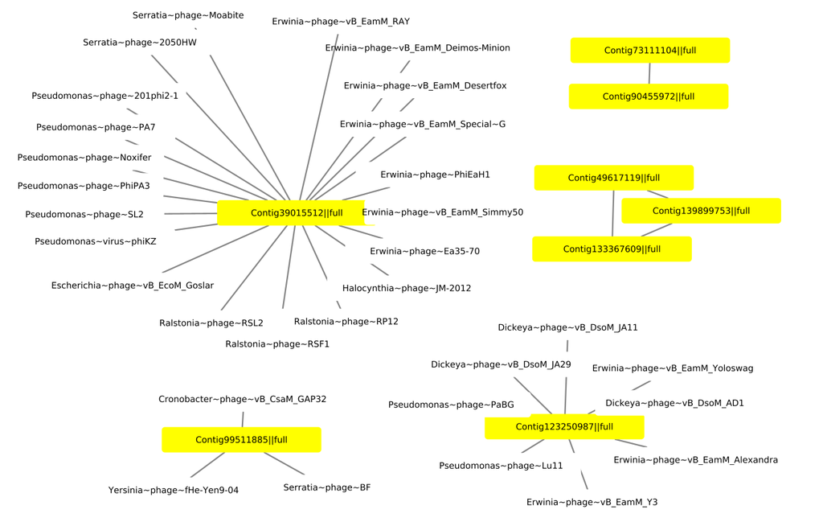

jumbo30

## DRAMv

### Data processing

#### Read files AMG summary and stats files

**R code**

```r
DRAMv_amg <- read_tsv("data_combined_assembly/DRAMv_amg_summary.tsv") |>
  rename("contig_id" = "scaffold")
DRAMv_stats <- read_tsv("data_combined_assembly/DRAMv_vMAG_stats.tsv") |>
  rename("contig_id" = "...1")
```

#### join with stats virsorter and checkv results

**R code**

```r
DRAMv_stats_virsorter_checkv_HQ <- left_join(virsorter_checkv_HQ, DRAMv_stats, by = "contig_id")
DRAMv_stats_virsorter_checkv_jumbo <- left_join(virsorter_checkv_jumbo, DRAMv_stats, by = "contig_id")
```

#### Add annotation to tibble with AMG names

**R code**

```r
DRAMv_amg_virsorter_checkv <- left_join(DRAMv_amg, virsorter_checkv, by = "contig_id")
```

#### filter amd files to HQ and jumbo

**R code**

```r
DRAMv_amg_virsorter_checkv_HQ <- DRAMv_amg_virsorter_checkv |>
filter(contig_id %in% HQ_contigs)

DRAMv_amg_virsorter_checkv_jumbo <- DRAMv_amg_virsorter_checkv |>
filter(contig_id %in% jumbo_contigs)
```

#### Write files

**R code**

```r
write_tsv(DRAMv_stats_virsorter_checkv_HQ, "data_combined_assembly/coa-DRAMv_stats_virsorter_checkv_HQ .tsv")
write_tsv(DRAMv_stats_virsorter_checkv_jumbo,"data_combined_assembly/coa-DRAMv_stats_virsorter_checkv_jumbo.tsv")
write_tsv(DRAMv_amg_virsorter_checkv_HQ, "data_combined_assembly/coa-DRAMv_amg_virsorter_checkv_HQ.tsv")
write_tsv(DRAMv_amg_virsorter_checkv_jumbo,"data_combined_assembly/coa-DRAMv_amg_virsorter_checkv_jumbo.tsv")
```

### Data Analysis

#### Graph of genes vs amgs in HQ

**R code**

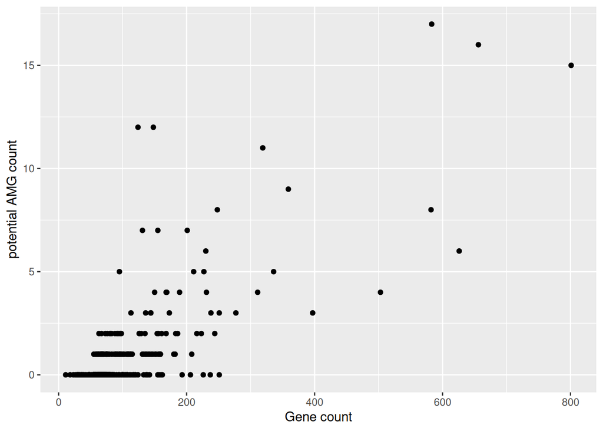

```r
DRAMv_stats_virsorter_checkv_HQ |>
ggplot(aes(x = `Gene count`, y = `potential AMG count`)) +
  geom_point()
```

#### Graph of genes vs amgs in HQ no provirus

**R code**

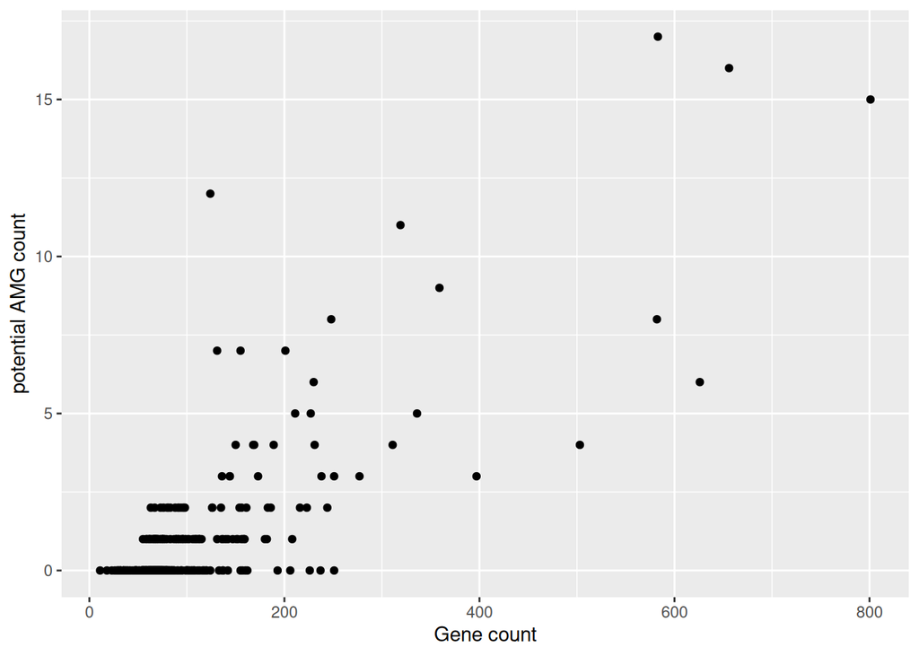

```r
DRAMv_stats_virsorter_checkv_HQ |>
  filter(provirus == "No") |>
ggplot(aes(x = `Gene count`, y = `potential AMG count`)) +
  geom_point()
```

#### Graph of genes vs iral genes with host benefits in HQ no provirus

**R code**

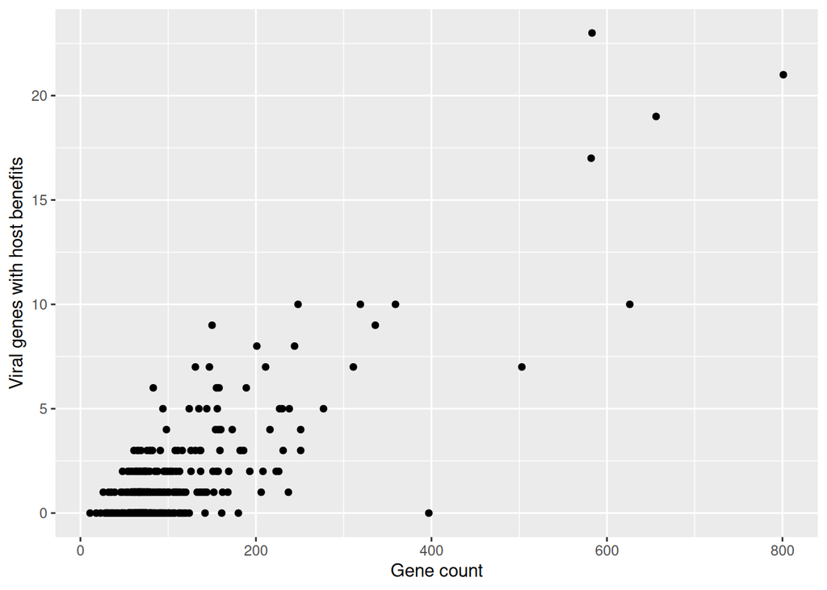

```r
DRAMv_stats_virsorter_checkv_HQ |>
  filter(provirus == "No") |>
ggplot(aes(x = `Gene count`, y = `Viral genes with host benefits`)) +
  geom_point()
```

#### Genome length vs gene count

**R code**

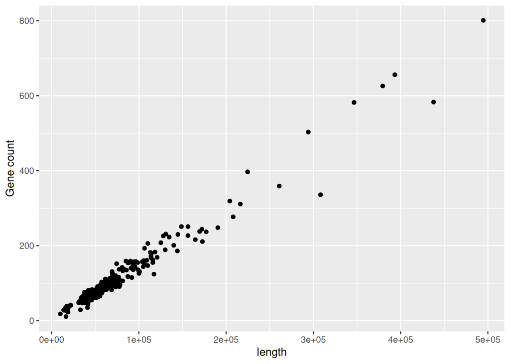

```r
DRAMv_stats_virsorter_checkv_HQ |>
    filter(provirus == "No") |>
ggplot(aes(x = `length`, y = `Gene count`)) +
  geom_point()
```

#### HQ contigs with transposes

**R code**

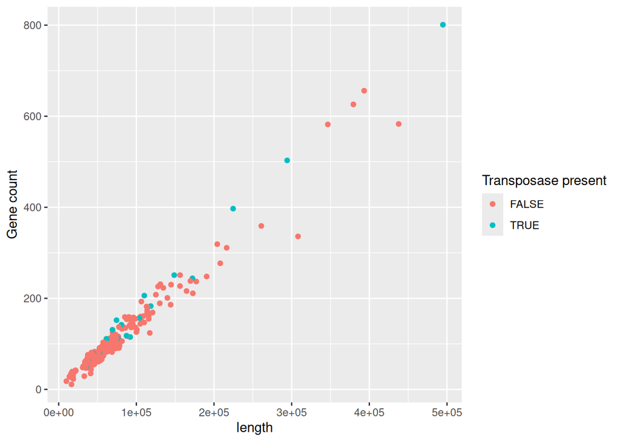

```r
DRAMv_stats_virsorter_checkv_HQ |>
    filter(provirus == "No") |>
ggplot(aes(x = `length`, y = `Gene count`)) +
  geom_point(aes(colour = `Transposase present`))
```

## virmatcher

### Data Processing

#### Join the virmatcher results csv with the virsorter_checkv_HQ and checkM_GTDB files to get virus and bacteria annotation

**R code**

```r
virmatch <- read_csv("data_combined_assembly/coa-virmatcher.csv") |>
  rename("contig_id" = "Original Viral population") |>
  rename("bin" = "Original Host")

checkm_gtdb <- read_tsv("data_combined_assembly/checkm_gtdb_NEB_coassembly_2.5k.tsv")

detect_viral_bins_final_calls <- read_tsv("data_combined_assembly/detect_viral_bins_final_calls.tsv")
```

#### Remove proviruses and low quality bins

**R code**

```r
virsorter_checkv_HQ_virmatch <- left_join(virsorter_checkv_HQ, virmatch, by = "contig_id")
virsorter_checkv_HQ_virmatch_checkm_gtdb <- left_join(virsorter_checkv_HQ_virmatch, checkm_gtdb, by = "bin") |>
  filter(Completeness > 50) |>
  filter(Contamination < 10)
```

Should check to see if any HQ phage are in bins which would complicate results. Find bin associated with contig

**R code**

```r
### to map contigs to bins
metabat_bins_contigs <- read_tsv("data_combined_assembly/metabat_depth_contigs.tsv") |>
  rename("contig_id" = "seqname") |>
  select(-c(contigLen, totalAvgDepth, `contig_%GC`))
virsorter_checkv_HQ_virmatch_checkm_gtdb$contig_id <- str_replace_all(virsorter_checkv_HQ_virmatch_checkm_gtdb$contig_id, "full", "")
virsorter_checkv_HQ_virmatch_checkm_gtdb$contig_id <- str_replace_all(virsorter_checkv_HQ_virmatch_checkm_gtdb$contig_id, "[[|]]", "")

virsorter_checkv_HQ_virmatch_checkm_gtdb_bin <- left_join(virsorter_checkv_HQ_virmatch_checkm_gtdb, metabat_bins_contigs, by = "contig_id")
write_tsv(virsorter_checkv_HQ_virmatch_checkm_gtdb_bin, "data_combined_assembly/virsorter_checkv_HQ_virmatch_checkm_gtdb_bin.tsv")
```

Genetic exchange shapes ultra-small Patescibacteria metabolic capacities in the terrestrial subsurface https://www.biorxiv.org/content/10.1101/2022.10.05.510940v2.full

https://journals.plos.org/plosbiology/article?id=10.1371/journal.pbio.3002083